# Final Report Analysis: Beneficiaries

Survey analysis output for cohorts 1 and 2 combined

Published

April 3, 2024

This html displays the key outputs of the analysis for the final sample (*N* = 83) of program participants (i.e, the beneficiaries). The table of contents on the left can be used to navigate across demographics, predictors, and outcomes. The only statistically significant finding was an association between recovery capital and the amount of time spent with a recovery coach on a weekly basis: compared to those who spent <1 hour/week with their coach, those who reported spending 9-16 hrs/week with their coaches had a much higher mean recovery capital score. *Please note that response rates are still being calculated and will be included in the final report draft

## Beneficiary Sample Characteristics_Demographics

For each demographic characteristic, an output table is presented to display these columns: the variable name, the sample size *n*, proportion, and response category.

### Gender

To help with output interpretation, we will explain the output table for this first demographic characteristic. The output table shows the variable name(**dem_gender**), and the *n* and **proportion** that selected each of the **response categories**. In this case, 48.19% (*n* = 40) of respondents self-reported as the response category of **male**.

```
  dem_gender  n proportion                  Gender
1          1 40 0.48192771                    Male
2          2 30 0.36144578                  Female
3          3  2 0.02409639              Non-binary
4          4  5 0.06024096 Prefer to self describe
5       <NA>  6 0.07228916            Missing Data
```

### Race

```
  dem_race  n proportion                             Race
1        1 46 0.55421687                            White
2        2 17 0.20481928        Black or African American
3        3  5 0.06024096 American Indian or Alaska Native
4        4  2 0.02409639        Asian or Pacific Islander
5        5  5 0.06024096                            Other
6        6  1 0.01204819                       Don't know
7     <NA>  7 0.08433735                     Missing Data
```

### Ethnicity

Are you of Hispanic, Latino/a, or Spanish origin?

```
  dem_ethnicity  n proportion Hispanic_Latino_Spanish_origin
1             1  8 0.09638554                            Yes
2             2 53 0.63855422                             No
3             3  1 0.01204819                     Don't Know
4          <NA> 21 0.25301205                   Missing Data
```

### Education

What is the highest grade or year of school you completed?

```
  dem_education  n proportion               HighestEducation
1             3  7 0.08433735               Some high school
2             4 29 0.34939759 High school grad or equivalent
3             5 31 0.37349398  Some college/technical school
4             6 11 0.13253012               College graduate
5          <NA>  5 0.06024096                   Missing Data
```

### Age

```
  dem_age  n proportion          Age
1       1  7 0.08433735        18-29
2       2 29 0.34939759        30-39
3       3 20 0.24096386        40-49
4       4 21 0.25301205        50-59
5       5  4 0.04819277        60-69
6       6  1 0.01204819        70-79
7    <NA>  1 0.01204819 Missing Data
```

## Beneficiary Sample Characteristics_ Predictors

### Beneficiary Predictor: Check in frequency with coach

How often do you communicate or check in with your PRC?

```
  prc_frequency  n proportion CoachCheckInFrequency
1             1  7 0.08433735  Multiple times a day
2             2 12 0.14457831          Once per day
3             3 36 0.43373494      1-4 times a week
4             4 13 0.15662651     1-2 times a month
5             6  4 0.04819277                 Other
6          <NA> 11 0.13253012          Missing Data
```

### Beneficiary Predictor: Hours with coach

About how many hours per week do you work with your RC?

```
  prc_hours  n proportion HoursWithCoach
1         1 16 0.19277108          <1 hr
2         2 39 0.46987952        1-4 hrs
3         3  9 0.10843373        5-8 hrs
4         4  2 0.02409639       9-16 hrs
5         5  4 0.04819277        17+ hrs
6         6  1 0.01204819          other
7      <NA> 12 0.14457831   Missing Data
```

## Beneficiary Sample Characteristics_ Outcomes

### Recovery Capital

```
  meanRecoveryCapital sdRecoveryCapital minRecoveryCapital maxRecoveryCapital
1            3.208295         0.7081124           1.181818           4.818182
```

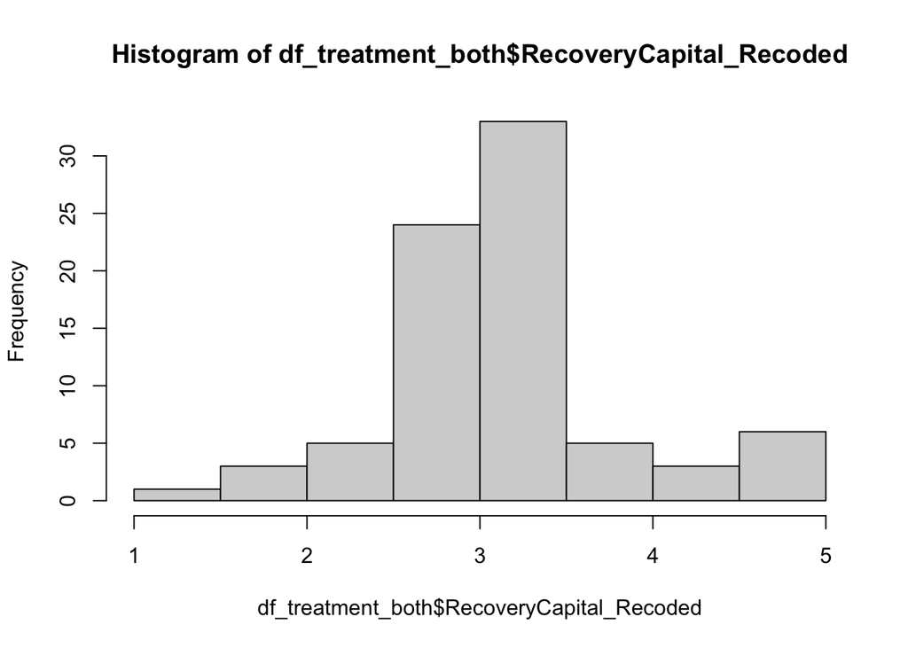

**Each of the 11 recovery capital items is summarized below**

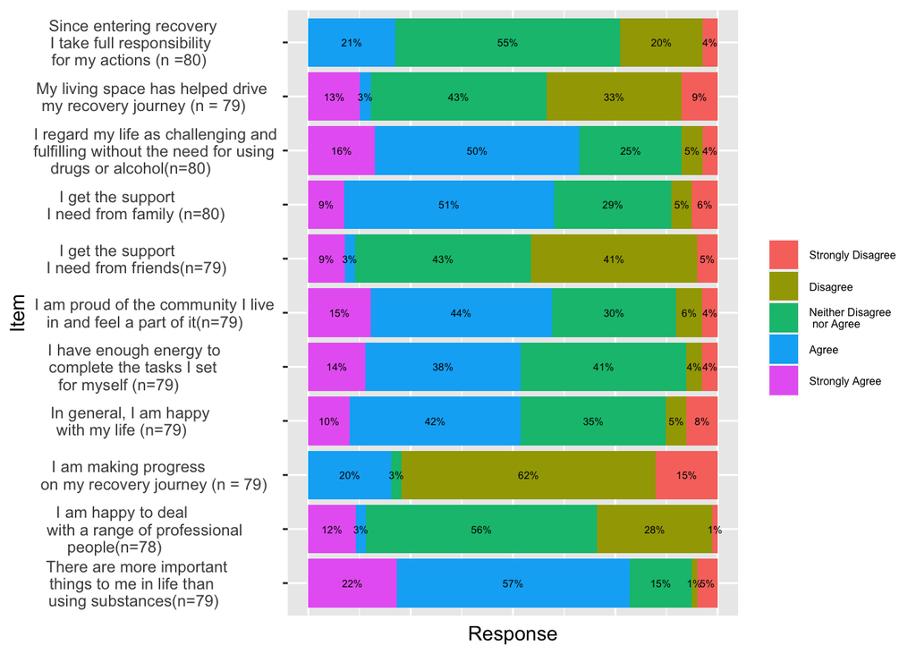

#### *Recovery Capital Regression: Does Frequency of Check-Ins with Coach Predict Recovery Capital?*

No significant effects found for frequency of coach checkins on recovery capital. The estimate trends suggest that, compared to seeing a coach multiple times/day, those who see their coaches less frequenty have lower recovery capital means.

```
Call:
lm(formula = RecoveryCapital_Recoded ~ prc_frequency, data = df_treatment_both)

Residuals:
     Min       1Q   Median       3Q      Max
-1.80722 -0.29545  0.01096  0.30303  1.66667

Coefficients:
               Estimate Std. Error t value Pr(>|t|)
(Intercept)     3.35065    0.24058  13.927   <2e-16 ***
prc_frequency2 -0.07489    0.30272  -0.247    0.805
prc_frequency3 -0.36161    0.26419  -1.369    0.176
prc_frequency4 -0.19913    0.30272  -0.658    0.513
prc_frequency6  0.21753    0.39895   0.545    0.587
---
Signif. codes:  0 '***' 0.001 '**' 0.01 '*' 0.05 '.' 0.1 ' ' 1

Residual standard error: 0.6365 on 64 degrees of freedom
  (14 observations deleted due to missingness)
Multiple R-squared:  0.07297,   Adjusted R-squared:  0.01503
F-statistic: 1.259 on 4 and 64 DF,  p-value: 0.2952
```

#### *Recovery Capital Regression: Does Time Spent with Coach Predict Recovery Capital?*

**Significant** difference in recovery capital observed where those who see their coaches 9-16hrs/week on average had 1 recovery capital higher mean score than those who see their coaches <1 hr/week.

```
Call:
lm(formula = RecoveryCapital_Recoded ~ prc_hours, data = df_treatment_both)

Residuals:
     Min       1Q   Median       3Q      Max
-1.81818 -0.36986 -0.00622  0.26806  1.63014

Coefficients:
            Estimate Std. Error t value Pr(>|t|)
(Intercept)  3.03052    0.16583  18.275   <2e-16 ***
prc_hours2   0.15752    0.19399   0.812   0.4199
prc_hours3  -0.03052    0.26510  -0.115   0.9087
prc_hours4   1.01494    0.46903   2.164   0.0343 *
prc_hours5   0.17403    0.35178   0.495   0.6226
prc_hours6   0.24221    0.64225   0.377   0.7074
---
Signif. codes:  0 '***' 0.001 '**' 0.01 '*' 0.05 '.' 0.1 ' ' 1

Residual standard error: 0.6205 on 62 degrees of freedom
  (15 observations deleted due to missingness)
Multiple R-squared:  0.08028,   Adjusted R-squared:  0.006108
F-statistic: 1.082 on 5 and 62 DF,  p-value: 0.379
```

### Drug Use in Past 30 Days

There was a discrepancy between cohorts with item wording where cohort 1 was asked “How often have you used opioids in the last 30 days?” while cohort 2 was asked “How often have you used drugs or alcohol in the last 30 days?”

There was also a discrepancy with item response choices where cohort 1 had:  
1 Once or more times a day  
2 A few times per week  
3 A few times per month  
4 Once a month. 5 I have not used opioids in the last 30 days

Cohort 2 had:  
1 Every day  
2 At least once a week  
3 At least once a month  
4 I have not used drugs in the last 30 days

Response 4 in C1 is unique to C1. Since Cohort 1 responses only had 1 or 5 responses, it is not a problem to remove option 4 from C1. The reconciled response scale will have 4 choices: Every day, At least once/week, At least once/month, and I have not used drugs in the last 30 days. Limitation in interpretation is that C1 asked only about opioids, while C2 asked about drugs.

#### Drug use in last 30 days: Sample characteristics

```
  use_drugs30days_recoded  n proportion
1                       1  5 0.06024096
2                       2  2 0.02409639
3                       3  2 0.02409639
4                       4 70 0.84337349
5                      NA  4 0.04819277
                                    DrugUse
1                                 Every day
2                      At least once a week
3                     At least once a month
4 I have not used drugs in the last 30 days
5                              Missing Data
```

#### **Drug Use: Does Frequency of Check-Ins with Coach Predict Drug Use?**

No significant effect of frequency of coach check ins for drug use in the past 30 days.

```
Call:
lm(formula = use_drugs30days_recoded ~ prc_frequency, data = df_treatment_both)

Residuals:
    Min      1Q  Median      3Q     Max
-2.5714  0.0000  0.1515  0.1515  0.5385

Coefficients:
               Estimate Std. Error t value Pr(>|t|)
(Intercept)      3.5714     0.2638  13.536   <2e-16 ***
prc_frequency2   0.4286     0.3320   1.291    0.201
prc_frequency3   0.2771     0.2905   0.954    0.344
prc_frequency4  -0.1099     0.3273  -0.336    0.738
prc_frequency6   0.4286     0.4375   0.980    0.331
---
Signif. codes:  0 '***' 0.001 '**' 0.01 '*' 0.05 '.' 0.1 ' ' 1

Residual standard error: 0.6981 on 64 degrees of freedom
  (14 observations deleted due to missingness)
Multiple R-squared:  0.07563,   Adjusted R-squared:  0.01786
F-statistic: 1.309 on 4 and 64 DF,  p-value: 0.2761
```

#### **Drug Use: Does Time Spent with Coach Predict Drug Use?**

No significant effect of weekly hours with coach for drug use in the past 30 days.

```
Call:
lm(formula = use_drugs30days_recoded ~ prc_hours, data = df_treatment_both)

Residuals:
    Min      1Q  Median      3Q     Max
-2.6757  0.0000  0.0000  0.3243  0.3243

Coefficients:
              Estimate Std. Error t value Pr(>|t|)
(Intercept)  4.000e+00  1.610e-01  24.844   <2e-16 ***
prc_hours2  -3.243e-01  1.909e-01  -1.699   0.0943 .
prc_hours3  -5.373e-15  2.629e-01   0.000   1.0000
prc_hours4   2.855e-17  4.694e-01   0.000   1.0000
prc_hours5   3.585e-17  3.509e-01   0.000   1.0000
prc_hours6   7.475e-17  6.440e-01   0.000   1.0000
---
Signif. codes:  0 '***' 0.001 '**' 0.01 '*' 0.05 '.' 0.1 ' ' 1

Residual standard error: 0.6236 on 62 degrees of freedom
  (15 observations deleted due to missingness)
Multiple R-squared:  0.06855,   Adjusted R-squared:  -0.006567
F-statistic: 0.9126 on 5 and 62 DF,  p-value: 0.4789
```

### Physical/Behavioral Services

Cohort 1 and Cohort 2 had differing response scales:  
C1: “Since entering recovery, how often have you utilized physical and/or behavioral health services on average? - Selected Choice” 1 Daily 2 Once per week or more 3 One or two times a month 4 A couple times a year 5 Less than two times a year 6 I do not attend health services 7 Other (fill-in)

C2: Since entering recovery, how often have you used physical and/or behavioral health services on average? 1 Every day 2 At least once a week 3 At least once a month 4 At least once a year 5 I do not attend health services

Response options 5 and 7 are unique to C1. However, no C1 respondent said “5”, so that can be omitted as a response choice (i.e., We can recode options 5 and 6 to become “I do not attend health services”.) N = 4 responses had “7 Other”. We will can now combine C1 and C2 to have options 1-7 (where 5 and 6 are “I do not attend services”, and 7 remains as Other. The limitation is that we didn’t give C2 respondents a chance to report “Other”).

#### Physical/Behavioral Service Use: Sample Characteristics

```
  use_physbehavservice_recoded  n proportion   UsePhysicalBehavioralServices
1                            1 17 0.20481928                           Daily
2                            2 30 0.36144578          At least once per week
3                            3 13 0.15662651         At least once per month
4                            4  5 0.06024096           A couple times a year
5                            5 11 0.13253012 I do not attend health services
6                            7  4 0.04819277                           Other
7                           NA  3 0.03614458                    Missing Data
```

####* Physical/Behavioral Services: Does the Frequency of Check-Ins with Coach Predict Use of Services?*

No significant effect of frequency of coach check ins for services use.

[output not shown]

####* Physical/Behavioral Services: Does Time Spent with Coach Predict Use of Services?*

No significant effect of weekly hours with coach for services use.

[output not shown]

### Culturally Appropriate Treatment Plans

**My treatment plan reflects my culture and worldview.** Responses were recorded on a 5-point Likert scale: Completely Very well Somewhat Not very well Not at all

```
  CulturalPlans  n proportion
1    Completely 48 0.57831325
2     Very well 24 0.28915663
3      Somewhat  9 0.10843373
4    Not at all  1 0.01204819
5  Missing Data  1 0.01204819
```

## Likely to recommend program to others

```
       recommend_program  n proportion
1            Very likely 63 0.75903614
2                 Likely 14 0.16867470
3 Not likely or unlikely  4 0.04819277
4          Very unlikely  1 0.01204819
5           Missing Data  1 0.01204819
```

## Service quality of organization

```
  services_quality  n proportion
1        Excellent 62 0.74698795
2             Good 17 0.20481928
3             Fair  4 0.04819277
```

## Service quality of recovery coach

```
   prc_quality  n proportion
1    Excellent 47 0.56626506
2         Good 14 0.16867470
3         Fair  1 0.01204819
4         Poor  1 0.01204819
5 Missing Data 20 0.24096386
```